# covid

```python
import numpy as np
import pandas as pd
import matplotlib.pyplot as plt
import seaborn as sns
```

## 0. Préalable

Chargement des données

```python
covid_0 = pd.read_excel('covid.xlsx')
```

```python
# on réalise une copie de notre dataset pour ne pas l'altérer durant notre étude
covid = covid_0.copy()
```

## 1. Exploratory Data Analysis (EDA)

### 1.1. Analyse de forme

Bref aperçu du contenu du dataset

```python
covid.sample(5) # visualiser un échantillon aléatoire du dataset
```

|  | Patient ID | Patient age quantile | SARS-Cov-2 exam result | Patient addmited to regular ward (1=yes, 0=no) | Patient addmited to semi-intensive unit (1=yes, 0=no) | Patient addmited to intensive care unit (1=yes, 0=no) | Hematocrit | Hemoglobin | Platelets | Mean platelet volume | ... | Hb saturation (arterial blood gases) | pCO2 (arterial blood gas analysis) | Base excess (arterial blood gas analysis) | pH (arterial blood gas analysis) | Total CO2 (arterial blood gas analysis) | HCO3 (arterial blood gas analysis) | pO2 (arterial blood gas analysis) | Arteiral Fio2 | Phosphor | ctO2 (arterial blood gas analysis) |
| --- | --- | --- | --- | --- | --- | --- | --- | --- | --- | --- | --- | --- | --- | --- | --- | --- | --- | --- | --- | --- | --- |
| 291 | 54e6578edb8ec65 | 16 | negative | 0 | 0 | 0 | 0.831618 | 0.541564 | -0.70584 | -0.999063 | ... | NaN | NaN | NaN | NaN | NaN | NaN | NaN | NaN | NaN | NaN |
| 2399 | c77e56d8cafab1b | 3 | negative | 0 | 0 | 0 | NaN | NaN | NaN | NaN | ... | NaN | NaN | NaN | NaN | NaN | NaN | NaN | NaN | NaN | NaN |
| 1838 | 2982175598001a0 | 5 | negative | 0 | 0 | 0 | NaN | NaN | NaN | NaN | ... | NaN | NaN | NaN | NaN | NaN | NaN | NaN | NaN | NaN | NaN |
| 3489 | a47dbcc99b7585a | 18 | negative | 0 | 0 | 0 | NaN | NaN | NaN | NaN | ... | NaN | NaN | NaN | NaN | NaN | NaN | NaN | NaN | NaN | NaN |
| 961 | 81a70c1476c9ccb | 8 | negative | 0 | 0 | 0 | NaN | NaN | NaN | NaN | ... | NaN | NaN | NaN | NaN | NaN | NaN | NaN | NaN | NaN | NaN |

5 rows × 111 columns

Dimension du dataset

```python
covid.shape # dimension du dataset (nombre de lignes, nombre de colonnes)
```

```
(5644, 111)
```

Analyse du type de chaque variable

```python
# pd.set_option('display.max_row', 111)
covid.dtypes # retourne le type de chaque variable
```

```
Patient ID                                                object
Patient age quantile                                       int64
SARS-Cov-2 exam result                                    object
Patient addmited to regular ward (1=yes, 0=no)             int64
Patient addmited to semi-intensive unit (1=yes, 0=no)      int64
Patient addmited to intensive care unit (1=yes, 0=no)      int64
Hematocrit                                               float64
Hemoglobin                                               float64
Platelets                                                float64
Mean platelet volume                                     float64
Red blood Cells                                          float64
Lymphocytes                                              float64
Mean corpuscular hemoglobin concentration (MCHC)         float64
Leukocytes                                               float64
Basophils                                                float64
Mean corpuscular hemoglobin (MCH)                        float64
Eosinophils                                              float64
Mean corpuscular volume (MCV)                            float64
Monocytes                                                float64
Red blood cell distribution width (RDW)                  float64
Serum Glucose                                            float64
Respiratory Syncytial Virus                               object
Influenza A                                               object
Influenza B                                               object
Parainfluenza 1                                           object
CoronavirusNL63                                           object
Rhinovirus/Enterovirus                                    object
Mycoplasma pneumoniae                                    float64
Coronavirus HKU1                                          object
Parainfluenza 3                                           object
Chlamydophila pneumoniae                                  object
Adenovirus                                                object
Parainfluenza 4                                           object
Coronavirus229E                                           object
CoronavirusOC43                                           object
Inf A H1N1 2009                                           object
Bordetella pertussis                                      object
Metapneumovirus                                           object
Parainfluenza 2                                           object
Neutrophils                                              float64
```

[output cut: 57 more lines]

```
Arterial Lactic Acid                                     float64
Lipase dosage                                            float64
D-Dimer                                                  float64
Albumin                                                  float64
Hb saturation (arterial blood gases)                     float64
pCO2 (arterial blood gas analysis)                       float64
Base excess (arterial blood gas analysis)                float64
pH (arterial blood gas analysis)                         float64
Total CO2 (arterial blood gas analysis)                  float64
HCO3 (arterial blood gas analysis)                       float64
pO2 (arterial blood gas analysis)                        float64
Arteiral Fio2                                            float64
Phosphor                                                 float64
ctO2 (arterial blood gas analysis)                       float64
dtype: object
```

```python
covid.dtypes.value_counts()
```

```
float64    70
object     37
int64       4
dtype: int64
```

Analyse des valeurs manquantes

```python
plt.figure(figsize=(20,10))
sns.heatmap(covid.isna(), cbar=False)
```

```python
# covid.isna().sum()
(covid.isna().sum() * 100 / covid.shape[0]).sort_values()
```

```
Patient ID                                                 0.000000
Patient age quantile                                       0.000000
SARS-Cov-2 exam result                                     0.000000
Patient addmited to regular ward (1=yes, 0=no)             0.000000
Patient addmited to semi-intensive unit (1=yes, 0=no)      0.000000
Patient addmited to intensive care unit (1=yes, 0=no)      0.000000
Influenza B                                               76.009922
Respiratory Syncytial Virus                               76.009922
Influenza A                                               76.009922
Rhinovirus/Enterovirus                                    76.045358
Inf A H1N1 2009                                           76.045358
CoronavirusOC43                                           76.045358
Coronavirus229E                                           76.045358
Parainfluenza 4                                           76.045358
Adenovirus                                                76.045358
Chlamydophila pneumoniae                                  76.045358
Parainfluenza 3                                           76.045358
Coronavirus HKU1                                          76.045358
CoronavirusNL63                                           76.045358
Parainfluenza 1                                           76.045358
Bordetella pertussis                                      76.045358
Parainfluenza 2                                           76.045358
Metapneumovirus                                           76.045358
Influenza A, rapid test                                   85.471297
Influenza B, rapid test                                   85.471297
Hemoglobin                                                89.316088
Hematocrit                                                89.316088
Red blood cell distribution width (RDW)                   89.333806
Platelets                                                 89.333806
Mean corpuscular volume (MCV)                             89.333806
Eosinophils                                               89.333806
Mean corpuscular hemoglobin (MCH)                         89.333806
Basophils                                                 89.333806
Leukocytes                                                89.333806
Mean corpuscular hemoglobin concentration (MCHC)          89.333806
Lymphocytes                                               89.333806
Red blood Cells                                           89.333806
Monocytes                                                 89.351524
Mean platelet volume                                      89.386960
Neutrophils                                               90.910702
```

[output cut: 57 more lines]

```
Base excess (arterial blood gas analysis)                 99.521616
Ferritin                                                  99.592488
Arteiral Fio2                                             99.645641
Phosphor                                                  99.645641
Albumin                                                   99.769667
Lipase dosage                                             99.858257
Vitamin B12                                               99.946846
Urine - Nitrite                                           99.982282
Fio2 (venous blood gas analysis)                          99.982282
Partial thromboplastin time (PTT)                        100.000000
Urine - Sugar                                            100.000000
Mycoplasma pneumoniae                                    100.000000
D-Dimer                                                  100.000000
Prothrombin time (PT), Activity                          100.000000
dtype: float64
```

76% -> tests viraux (bactéries, virus)  
89% -> tests sanguins (cellules)

### 1.2. Analyse de fond

Elimination des colonnes inutiles

```python
covid.dropna(axis=1, how='all', inplace=True) # suppression des colonnes vides
covid.shape
```

```
(5644, 106)
```

```python
covid = covid[covid.columns[covid.isna().sum() / covid.shape[0] < 0.9]] # suppression de toutes les colonnes avec plus de 90% de valeurs manquantes
covid.shape
```

```
(5644, 39)
```

```python
covid.drop('Patient ID', axis=1, inplace=True) # suppression de l'identifiant des patients
```

```python
covid.sample(3)
```

|  | Patient age quantile | SARS-Cov-2 exam result | Patient addmited to regular ward (1=yes, 0=no) | Patient addmited to semi-intensive unit (1=yes, 0=no) | Patient addmited to intensive care unit (1=yes, 0=no) | Hematocrit | Hemoglobin | Platelets | Mean platelet volume | Red blood Cells | ... | Adenovirus | Parainfluenza 4 | Coronavirus229E | CoronavirusOC43 | Inf A H1N1 2009 | Bordetella pertussis | Metapneumovirus | Parainfluenza 2 | Influenza B, rapid test | Influenza A, rapid test |
| --- | --- | --- | --- | --- | --- | --- | --- | --- | --- | --- | --- | --- | --- | --- | --- | --- | --- | --- | --- | --- | --- |
| 1290 | 7 | negative | 0 | 0 | 0 | NaN | NaN | NaN | NaN | NaN | ... | NaN | NaN | NaN | NaN | NaN | NaN | NaN | NaN | NaN | NaN |
| 186 | 11 | negative | 0 | 0 | 0 | -0.038148 | 0.102972 | 0.173487 | -1.335643 | 0.36646 | ... | NaN | NaN | NaN | NaN | NaN | NaN | NaN | NaN | negative | negative |
| 949 | 2 | negative | 0 | 0 | 0 | NaN | NaN | NaN | NaN | NaN | ... | not_detected | not_detected | not_detected | not_detected | not_detected | not_detected | not_detected | not_detected | NaN | NaN |

3 rows × 38 columns

Visualisation de la target

```python
# covid['SARS-Cov-2 exam result'].value_counts()
covid['SARS-Cov-2 exam result'].value_counts(normalize=True) * 100
```

```
negative    90.113395
positive     9.886605
Name: SARS-Cov-2 exam result, dtype: float64
```

Histogramme des variables continues

```python
# visualisation des variables flottantes
for colonne in covid.select_dtypes('float'):
	plt.figure()
	sns.distplot(covid[colonne])
```

```python
sns.distplot(covid['Patient age quantile'], bins=20) # visualisation de l'age
```

Visualisation des variables discrètes

```python
for colonne in covid.select_dtypes('object'):
	print(f'{colonne :-<30} {covid[colonne].unique()}')
```

```
SARS-Cov-2 exam result-------- ['negative' 'positive']
Respiratory Syncytial Virus--- [nan 'not_detected' 'detected']
Influenza A------------------- [nan 'not_detected' 'detected']
Influenza B------------------- [nan 'not_detected' 'detected']
Parainfluenza 1--------------- [nan 'not_detected' 'detected']
CoronavirusNL63--------------- [nan 'not_detected' 'detected']
Rhinovirus/Enterovirus-------- [nan 'detected' 'not_detected']
Coronavirus HKU1-------------- [nan 'not_detected' 'detected']
Parainfluenza 3--------------- [nan 'not_detected' 'detected']
Chlamydophila pneumoniae------ [nan 'not_detected' 'detected']
Adenovirus-------------------- [nan 'not_detected' 'detected']
Parainfluenza 4--------------- [nan 'not_detected' 'detected']
Coronavirus229E--------------- [nan 'not_detected' 'detected']
CoronavirusOC43--------------- [nan 'not_detected' 'detected']
Inf A H1N1 2009--------------- [nan 'not_detected' 'detected']
Bordetella pertussis---------- [nan 'not_detected' 'detected']
Metapneumovirus--------------- [nan 'not_detected' 'detected']
Parainfluenza 2--------------- [nan 'not_detected']
Influenza B, rapid test------- [nan 'negative' 'positive']
Influenza A, rapid test------- [nan 'negative' 'positive']
```

```python
for colonne in covid.select_dtypes('object'):
	plt.figure()
	covid[colonne].value_counts().plot.pie()
```

Création de sous-ensembles positifs et négatifs

```python
positive_covid = covid[covid['SARS-Cov-2 exam result']	== 'positive']
negative_covid = covid[covid['SARS-Cov-2 exam result']	== 'negative']
```

Création des sous-ensembles Virus et Sang

```python
missing_rate = covid.isna().sum() / covid.shape[0]
blood_columns = covid.columns[(missing_rate < 0.9) & (missing_rate > 0.88)]
viral_columns = covid.columns[(missing_rate < 0.87) & (missing_rate > 0.75)]
```

Relation target/blood

```python
for colonne in blood_columns:
	plt.figure()
	sns.distplot(positive_covid[colonne], label='positive')
	sns.distplot(negative_covid[colonne], label='negative')
	plt.legend()
```

Relation target/age

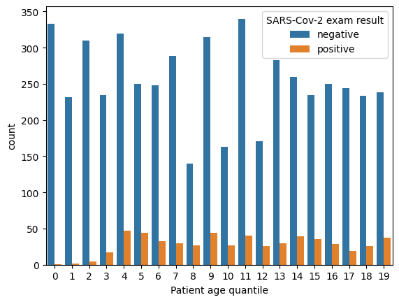

```python
sns.countplot(data=covid, x='Patient age quantile', hue='SARS-Cov-2 exam result')
```

Relation target/viral

```python
for colonne in viral_columns:
	plt.figure()
	sns.heatmap(pd.crosstab(covid['SARS-Cov-2 exam result'], covid[colonne]), annot=True, fmt='d')
```

> Résumé de l'analyse de fond
1. **Visualisation de la target :** 10% de cas positifs
2. **Signification des variables :**
- variables continues standardisées, skewed (asymétriques), test sanguin
- age quantile : graphique difficile à interpréter car les données ont été traitées et la nature de ce traitement est inconnue
- variables qualitatives : binaires, virales, Rhinovirus très varié
3. **Visualisation des relations features/target :**
- target/blood : les taux de leucocytes, monocytes et plaquettes semblent liés au covid 19
- target/age : les individus d'age faible sont très peu contaminés
- target/viral : les doubles maladies sont très rares. Rhinovirus/Enterovirus positif => covid 19 positif ?

> Conclusions initiales de l'EDA
> - Beacoup de données manquantes (au mieux, on garde 20% du dataset)
> - 2 groupes de données intéressantes (viral et sanguin)
> - Presque pas de variable discriminante pour distinguer les cas positifs/négatifs.

### Analyse plus détaillée

Relations variables/variables

Relations taux sanguin

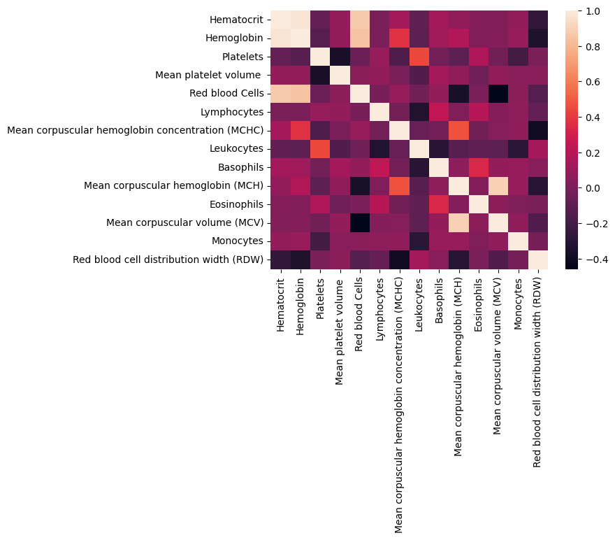

```python
sns.heatmap(covid[blood_columns].corr())
```

Relations age/sang

```python
for colonne in blood_columns:
	plt.figure()
	sns.lmplot(data=covid, x='Patient age quantile', y=colonne, hue='SARS-Cov-2 exam result')
```

```python
covid.corr()['Patient age quantile'].sort_values()
```

```
C:\Users\Juste KOUASSI\AppData\Local\Temp\ipykernel_15248\3721253062.py:1: FutureWarning: The default value of numeric_only in DataFrame.corr is deprecated. In a future version, it will default to False. Select only valid columns or specify the value of numeric_only to silence this warning.
  covid.corr()['Patient age quantile'].sort_values()
```

```
Leukocytes                                              -0.166386
Platelets                                               -0.158683
Lymphocytes                                             -0.125935
Mean corpuscular hemoglobin concentration (MCHC)        -0.124671
Red blood Cells                                         -0.037510
Patient addmited to intensive care unit (1=yes, 0=no)   -0.035772
Patient addmited to semi-intensive unit (1=yes, 0=no)    0.015736
Eosinophils                                              0.022085
Patient addmited to regular ward (1=yes, 0=no)           0.046166
Monocytes                                                0.050962
Hemoglobin                                               0.060320
Hematocrit                                               0.096808
Basophils                                                0.107525
Mean platelet volume                                     0.119449
Red blood cell distribution width (RDW)                  0.166429
Mean corpuscular hemoglobin (MCH)                        0.197394
Mean corpuscular volume (MCV)                            0.281655
Patient age quantile                                     1.000000
Name: Patient age quantile, dtype: float64
```

Relations viral/viral

```python
pd.crosstab(covid['Influenza A'], covid['Influenza A, rapid test'])
```

| Influenza A, rapid test Influenza A | negative | positive |
| --- | --- | --- |
| detected | 2 | 4 |
| not_detected | 245 | 15 |

```python
pd.crosstab(covid['Influenza B'], covid['Influenza B, rapid test'])
```

| Influenza B, rapid test Influenza B | negative | positive |
| --- | --- | --- |
| detected | 18 | 11 |
| not_detected | 233 | 4 |

Relations viral/sanguin

Création d'une nouvelle variable "est_malade"

```python
covid["is_sick"] = np.sum(covid[viral_columns[:-2]] == 'detected', axis=1) >= 1
covid.sample(3)
```

```
C:\Users\Juste KOUASSI\AppData\Local\Temp\ipykernel_15248\1759111187.py:1: SettingWithCopyWarning:
A value is trying to be set on a copy of a slice from a DataFrame.
Try using .loc[row_indexer,col_indexer] = value instead

See the caveats in the documentation: https://pandas.pydata.org/pandas-docs/stable/user_guide/indexing.html#returning-a-view-versus-a-copy
  covid["is_sick"] = np.sum(covid[viral_columns[:-2]] == 'detected', axis=1) >= 1
```

[output not shown]

```python
sick_rows = covid[covid['is_sick'] == True]
healthy_rows = covid[covid['is_sick'] == False]
```

```python
covid.sample(3)
```

|  | Patient age quantile | SARS-Cov-2 exam result | Patient addmited to regular ward (1=yes, 0=no) | Patient addmited to semi-intensive unit (1=yes, 0=no) | Patient addmited to intensive care unit (1=yes, 0=no) | Hematocrit | Hemoglobin | Platelets | Mean platelet volume | Red blood Cells | ... | Parainfluenza 4 | Coronavirus229E | CoronavirusOC43 | Inf A H1N1 2009 | Bordetella pertussis | Metapneumovirus | Parainfluenza 2 | Influenza B, rapid test | Influenza A, rapid test | is_sick |
| --- | --- | --- | --- | --- | --- | --- | --- | --- | --- | --- | --- | --- | --- | --- | --- | --- | --- | --- | --- | --- | --- |
| 904 | 1 | negative | 0 | 0 | 0 | NaN | NaN | NaN | NaN | NaN | ... | NaN | NaN | NaN | NaN | NaN | NaN | NaN | NaN | NaN | False |
| 1372 | 10 | negative | 0 | 0 | 0 | NaN | NaN | NaN | NaN | NaN | ... | NaN | NaN | NaN | NaN | NaN | NaN | NaN | NaN | NaN | False |
| 731 | 16 | negative | 0 | 0 | 0 | NaN | NaN | NaN | NaN | NaN | ... | NaN | NaN | NaN | NaN | NaN | NaN | NaN | NaN | NaN | False |

3 rows × 39 columns

```python
for colonne in blood_columns:
	plt.figure()
	sns.distplot(sick_rows[colonne], label='sick')
	sns.distplot(healthy_rows[colonne], label='healthy')
	plt.legend()
```

Relation hospitalisation/malade

```python
def hospitalisation(df: pd.DataFrame):
	if df['Patient addmited to regular ward (1=yes, 0=no)'] == 1:
		return 'surveillance'
	elif df['Patient addmited to semi-intensive unit (1=yes, 0=no)'] == 1:
		return 'soins semi-intensifs'
	elif df['Patient addmited to intensive care unit (1=yes, 0=no)'] == 1:
		return 'soins intensifs'
	else:
		return 'inconnu'
```

```python
covid['statut'] = covid.apply(hospitalisation, axis=1)
```

```python
covid.sample(3)
```

|  | Patient age quantile | SARS-Cov-2 exam result | Patient addmited to regular ward (1=yes, 0=no) | Patient addmited to semi-intensive unit (1=yes, 0=no) | Patient addmited to intensive care unit (1=yes, 0=no) | Hematocrit | Hemoglobin | Platelets | Mean platelet volume | Red blood Cells | ... | Coronavirus229E | CoronavirusOC43 | Inf A H1N1 2009 | Bordetella pertussis | Metapneumovirus | Parainfluenza 2 | Influenza B, rapid test | Influenza A, rapid test | is_sick | statut |
| --- | --- | --- | --- | --- | --- | --- | --- | --- | --- | --- | --- | --- | --- | --- | --- | --- | --- | --- | --- | --- | --- |
| 4291 | 16 | negative | 0 | 0 | 0 | NaN | NaN | NaN | NaN | NaN | ... | NaN | NaN | NaN | NaN | NaN | NaN | NaN | NaN | False | inconnu |
| 515 | 17 | negative | 0 | 0 | 0 | NaN | NaN | NaN | NaN | NaN | ... | NaN | NaN | NaN | NaN | NaN | NaN | NaN | NaN | False | inconnu |
| 2638 | 18 | negative | 0 | 0 | 0 | NaN | NaN | NaN | NaN | NaN | ... | NaN | NaN | NaN | NaN | NaN | NaN | NaN | NaN | False | inconnu |

3 rows × 40 columns

```python
for colonne in blood_columns:
	plt.figure()
	for cat in covid['statut'].unique():
		sns.distplot(covid[covid['statut'] == cat][colonne], label=cat)
	plt.legend()
```

Relations variables/variables :

- blood_data/blood_data : certaines variables sont très corrélées (+0.9)
- blood_data/age : très faible corrélation entre l'age et le taux sanguin
- viral/viral : le test rapide de grippe donne de mauvais résultats. Il faudra peut-être la laisser tomber
- relation maladie/blood_data : les taux sanguins entre malades et covid 19 sont différents
- relation hospitalisation/malade :
- relation hospitalisation/blood : intéressant dans le cas où on voudrait prédire dans quel service un patient devrait aller

Analyse NaN : viral ~ 1350 (92/8), blood ~ 600 (86/14), both (90/10)

Hypothèses de départ :

- Les individus atteints du covid 19 ont des taux de leucocytes, monocytes, plaquettes significativement différents
- Soit H0 = Les taux moyens sont égaux chez les individus positifs et négatifs
- Les individus atteints d'une quelonque maladie ont des taux significativement différents

### T-Test

```python
from scipy.stats import ttest_ind
```

```python
print(positive_covid.shape, negative_covid.shape)
# les deux tableaux ne comportent pas le même nombre de lignes
```

```
(558, 38) (5086, 38)
```

```python
balance_neg = negative_covid.sample(positive_covid.shape[0])
```

```python
def t_test(colonne):
	alpha = 0.02
	stat, p = ttest_ind(balance_neg[colonne].dropna(), positive_covid[colonne].dropna())
	if p < alpha:
		return 'H0 rejetée'
	else:
		return 'H0 acceptée'
```

```python
for colonne in blood_columns:
	print(f'{colonne :-<50} {t_test(colonne)}')
```

```
Hematocrit---------------------------------------- H0 rejetée
Hemoglobin---------------------------------------- H0 rejetée
Platelets----------------------------------------- H0 rejetée
Mean platelet volume ----------------------------- H0 acceptée
Red blood Cells----------------------------------- H0 rejetée
Lymphocytes--------------------------------------- H0 acceptée
Mean corpuscular hemoglobin concentration (MCHC)-- H0 acceptée
Leukocytes---------------------------------------- H0 rejetée
Basophils----------------------------------------- H0 acceptée
Mean corpuscular hemoglobin (MCH)----------------- H0 acceptée
Eosinophils--------------------------------------- H0 rejetée
Mean corpuscular volume (MCV)--------------------- H0 acceptée
Monocytes----------------------------------------- H0 rejetée
Red blood cell distribution width (RDW)----------- H0 acceptée
```